# Graphical options with `plot_fullsibQTL`

In this tutorial we show how to plot different graphics with the `plot_fullsibQTL` function. A complete description can be viewed through `?plot_fullsibQTL`. As an example we will use the example data from the package, the below step are described at the *`fullsibQTL` Tutorial* vignette.

```r
  library( "fullsibQTL" )
  data( "example_QTLfullsib" )
  fullsib <- create_fullsib( example_QTLfullsib,
                             list( LG1_final, LG2_final, LG3_final, LG4_final ),
                             step = 1,
                             map.function = "kosambi",
                             condIndex = 3.5 )

  ## IM
  im <- im_scan( fullsib )
  qtls.im <- r2_ls( fullsib,
                    pheno.col = 1,
                    lg = c( 1, 1, 2, 2, 2, 3, 3, 4 ),
                    pos = c( "loc13", "M12", "loc45", "loc77", "loc108", "M33", "loc65", "M52" ) )

  ## CIM
  cofs.fs <- cof_selection( fullsib,
                            pheno.col = 1,
                            k=log(300),
                            n.cofactor = 10)
  cim <- cim_scan( cofs.fs )
  qtls.cim <- r2_ls( fullsib,
                     pheno.col = 1,
                     lg = c( 1, 1, 2, 2, 2, 3, 3, 4 ),
                     pos = c( "loc13", "M12", "loc45", "loc77", "loc108", "M33", "loc65", "M52" ) )

  ## Getting im and cim peaks for alpha 0.05.
  im.peak1 <- summary( im_perm, alpha = 0.05 )[ 1, 1 ]
  im.peak2 <- summary( im_perm, alpha = 0.05 )[ 1, 2 ]

  cim.peak1 <- summary( cim_perm, alpha = 0.05 )[ 1, 1 ]
  cim.peak2 <- summary( cim_perm, alpha = 0.05 )[ 1, 2 ]
```

## Customizing Graphics

The minimal plot has to have the fullsib object and at list one result of `fullsib_scan`. At the bottom of the graphic it is shown the genetic map.

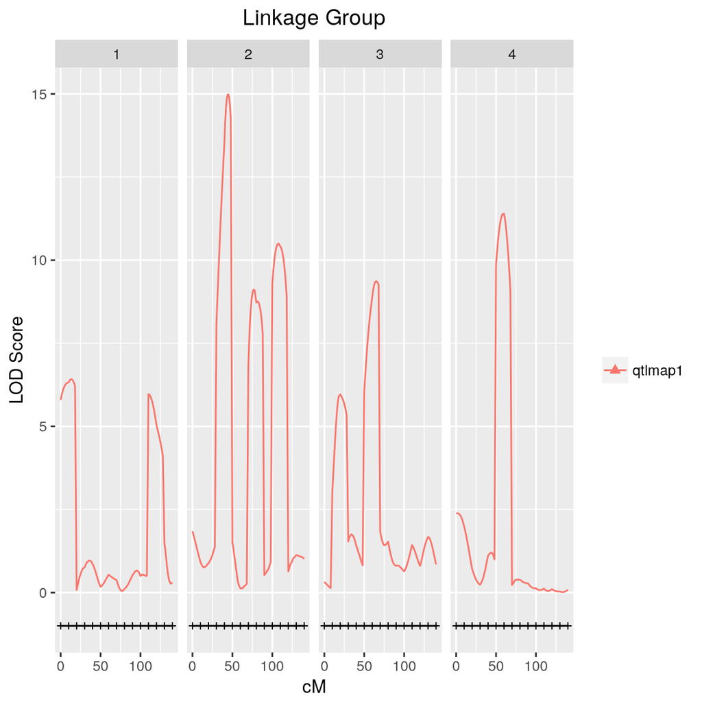

```r
plot_fullsibQTL( fullsib = fullsib,
                 fullsib.scan = cim )
```

We can set the legend of the QTL mapping with the `qtlmapping` argument:

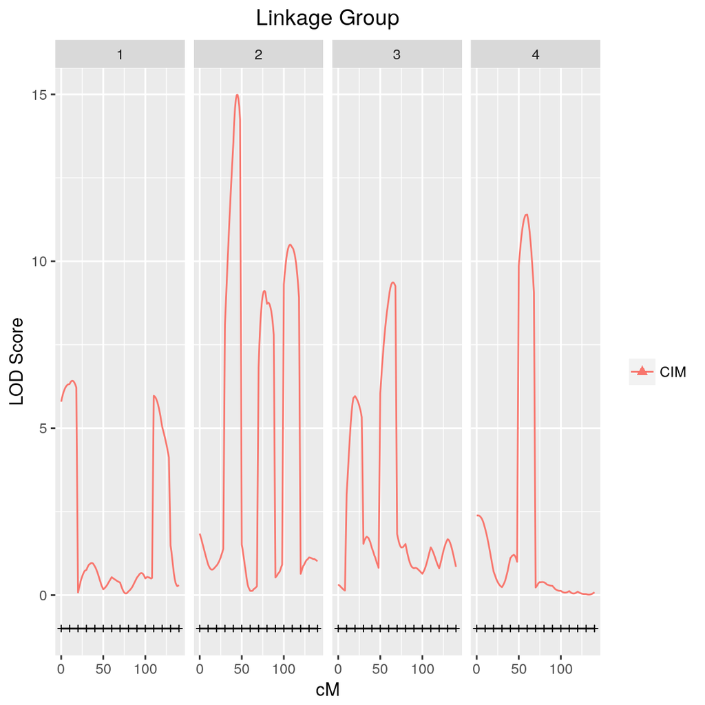

```r
plot_fullsibQTL( fullsib = fullsib,
                 fullsib.scan = cim,
                 qtlmapping = "CIM" )
```

## Graphical comparision between different `(c)im_scan`

There is the option to insert multiple results from `(c)im_scan` with listing them with `list()`. Those multiple results can be different traits, a same trait in different environments, comparision of IM $\times$ CIM, and so on. Here we compare IM $\times$ CIM

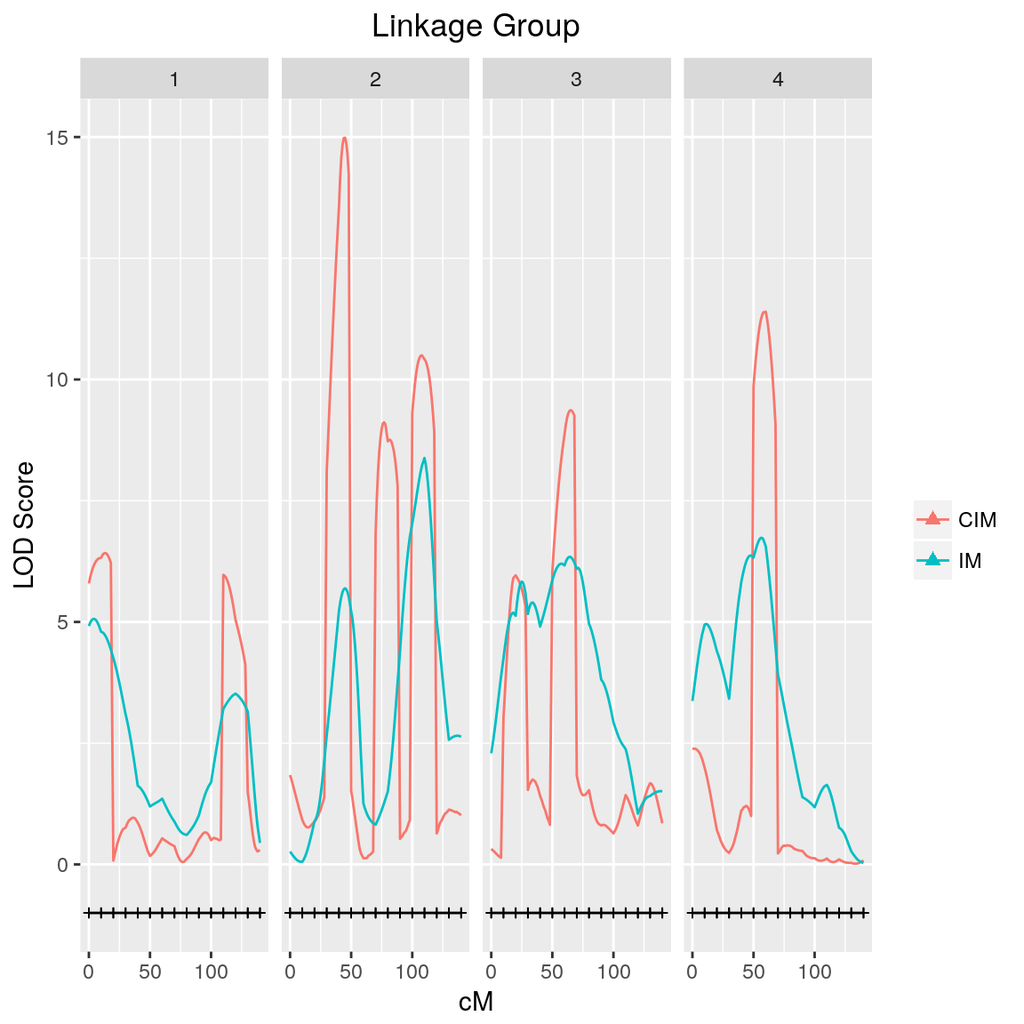

```r
plot_fullsibQTL( fullsib=fullsib,
                 fullsib.scan=list(cim,im),
                 qtlmapping = c( "CIM", "IM" ) )
```

## Adding QTL location to the graphic

You can insert the QTLs position from the `r2_ls` function for each one of the `(c)im_scan`. In order to do it, you need to use the argument `r2ls.out`:

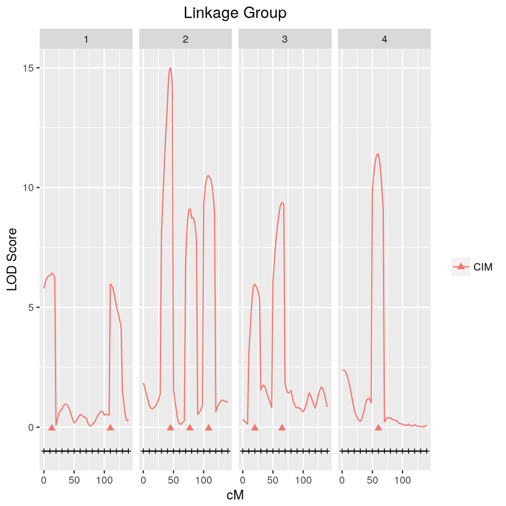

```r
plot_fullsibQTL( fullsib = fullsib,
                 fullsib.scan = cim,
                 r2ls.out = qtls.cim,
                 qtlmapping = "CIM" )
```

For multiple QTLs mappings:

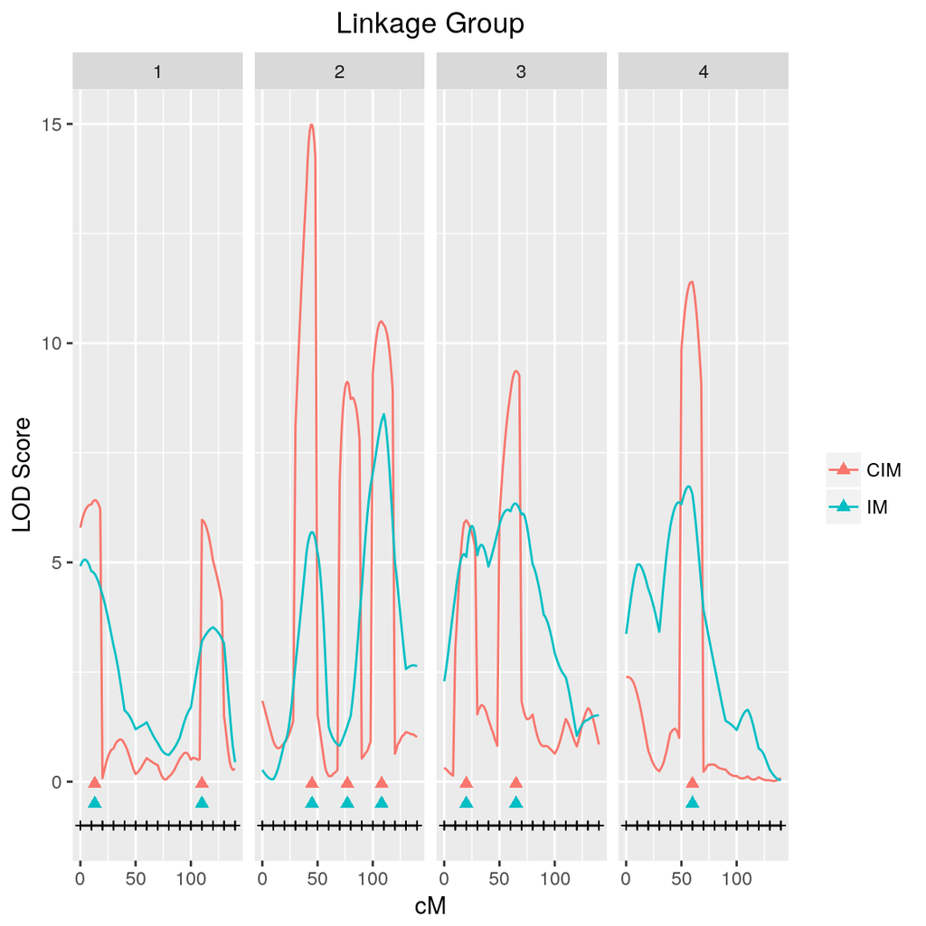

```r
plot_fullsibQTL( fullsib = fullsib,
                 fullsib.scan = list( cim, im ),
                 r2ls.out = list( qtls.cim, qtls.im ),
                 qtlmapping = c( "CIM", "IM" ) )
```

```r
summary( cim_perm )
```

```
#>  Threshold considering 1000 permutations
#>        peak.1   peak.2   peak.3   peak.4
#> 0.05 4.023724 2.900906 2.300657 1.860476
#> 0.1  3.707559 2.650663 2.140063 1.692707
```

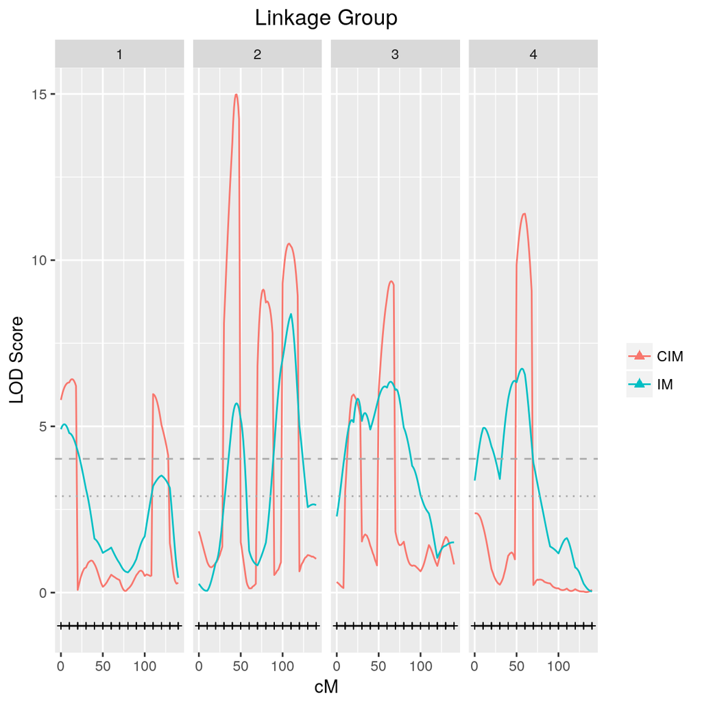

```r
plot_fullsibQTL( fullsib = fullsib,
                 fullsib.scan = list ( cim, im ),
                 qtlmapping = c( "CIM", "IM" ),
                 thr = c(4.023724, 2.900906 ) )
```

For printing purposes, another option is to change the graphic for a grayscale:

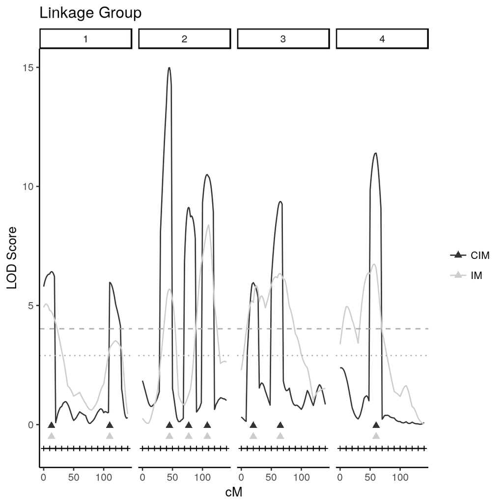

```r
plot_fullsibQTL( fullsib = fullsib,
                 fullsib.scan = list( cim, im ),
                 r2ls.out = list( qtls.cim, qtls.im ),
                 qtlmapping = c( "CIM", "IM" ),
                 thr = c( 4.023724, 2.900906 ),
                 grayscale = TRUE )
```

There is the option to set which linkage groups you want to plot. To plot just LG 2:

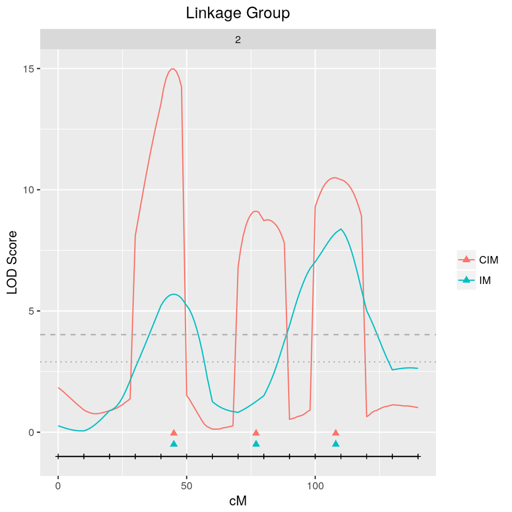

```r
plot_fullsibQTL( fullsib = fullsib,
                 fullsib.scan = list( cim, im ),
                 r2ls.out = list( qtls.cim, qtls.im ),
                 qtlmapping = c( "CIM", "IM" ),
                 thr = c( 4.023724, 2.900906 ),
                 lgs = 2 )
```

To plot LG 2 and 4:

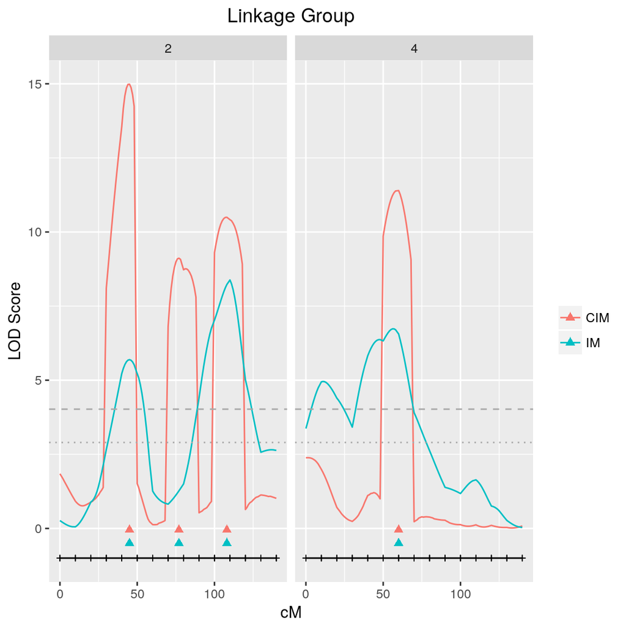

```r
plot_fullsibQTL( fullsib = fullsib,
                 fullsib.scan = list( cim, im ),
                 r2ls.out = list( qtls.cim, qtls.im ),
                 qtlmapping = c( "CIM", "IM" ),
                 thr = c( 4.023724, 2.900906 ),
                 lgs = c( 2, 4 ) )
```

## Interactive plot

There is also the option to plot a interactive graphic. Inside the function, we use the package `plotly` as the engine. With the option `interact=TRUE` it will be created an interactive `html` graphic in you working directory folder or you can set the folder name to create the `html`. The plot will be returned in your default browser. If you do not want to open the browser, set `browser=FALSE`

```r
## Setting the file name
plot_fullsibQTL( fullsib = fullsib,
                 fullsib.scan = list( cim, im ),
                 r2ls.out = list( qtls.cim, qtls.im ),
                 qtlmapping = c ( "CIM", "IM" ),
                 thr = c( 4.023724, 2.900906 ),
                 interact = TRUE,
                 file = "cim_im.html" )

## Setting the folder name
plot_fullsibQTL( fullsib = fullsib,
                 fullsib.scan = list( cim, im ),
                 r2ls.out = list( qtls.cim, qtls.im ),
                 qtlmapping = c( "CIM", "IM" ),
                 thr = c( 4.023724, 2.900906 ),
                 interact = TRUE,
                 file = "cim_im.html",
                 folder = "/home/your_user_name/graphics" )

## Setting to not open the browser
plot_fullsibQTL( fullsib = fullsib,
                 fullsib.scan = list( cim, im ),
                 r2ls.out = list( qtls.cim, qtls.im ),
                 qtlmapping = c( "CIM", "IM" ),
                 thr = c( 4.023724, 2.900906 ),
                 interact = TRUE,
                 file = "cim_im.html",
                 folder = "/home/your_user_name/Pictures",
                 browser = FALSE )
```

The above script creates the following graphic. It is a interactive `plotly`. *Click on legend entries to toggle traces, click-and-drag on the chart to zoom, double-click to autoscale, shift-and-drag to pan* ([plotly website](https://plot.ly/r/getting-started/)). Additionaly, it is included in the tooltip the LOD score, the QTL estimated effect, and marker names in the map.

cim_im.html

The user can also set the height and width of the interact plot within the arguments `height` and `width`, they are the same as the arguments of `plotly` function. The default of `height` is 500 pixels and for `width` is 250 $\times$ the number of LGs to be plot. All the arguments can be combined in the interactive plot.

## Changing colors

There is the option to choose the colors for each LG, the argument `lg.colors` will pass its values to the `ggplot2::scale_colour_manual` function. You can check more colors options at this [cheatsheet](https://www.nceas.ucsb.edu/~frazier/RSpatialGuides/colorPaletteCheatsheet.pdf) or at this color [guide](http://www.stat.columbia.edu/~tzheng/files/Rcolor.pdf).

```r
plot_fullsibQTL( fullsib = fullsib,
                 fullsib.scan = list( cim, im ),
                 r2ls.out = list( qtls.cim, qtls.im ),
                 qtlmapping = c( "CIM", "IM" ),
                 thr = c( 4.023724, 2.900906 ),
                 lgs = c( 2, 4 ),
                 interact = TRUE,
                 lg.colors = c( "darkgreen", "green" ),
                 height = 600,
                 width = 800,
                 file = "cim_im_greens.html",
                 folder="/home/your_user_name/graphics" )
```

cim_im_greens.html

[Statistical Genetics Lab](http://statgen.esalq.usp.br)  
Department of Genetics  
Luiz de Queiroz College of Agriculture  
University of São Paulo

2017-08-23